Author: Khorloo Batpurev title: “Chapter3” output: html_document date: “2023-11-20”

# Week 3 - Logistic Regression

```r
date()
```

```
## [1] "Tue Nov 21 17:01:07 2023"
```

#### **Task 1 - Describe the data briefly**

This is the dataframe saved locally on my computer

```r
library(tidyverse)
unique_students<-read_csv("students_from_math_and_porteguese_classes_and_alc_consumption.csv")
glimpse(unique_students)
```

```
## Rows: 370
## Columns: 44
## $ school             <chr> "GP", "GP", "GP", "GP", "GP", "GP", "GP", "GP", "GP…
## $ sex                <chr> "F", "F", "F", "F", "F", "F", "F", "F", "F", "F", "…
## $ age                <dbl> 15, 15, 15, 15, 15, 15, 15, 15, 15, 15, 15, 15, 15,…
## $ address            <chr> "R", "R", "R", "R", "R", "R", "R", "R", "R", "U", "…
## $ famsize            <chr> "GT3", "GT3", "GT3", "GT3", "GT3", "GT3", "GT3", "L…
## $ Pstatus            <chr> "T", "T", "T", "T", "T", "T", "T", "T", "T", "A", "…
## $ Medu               <dbl> 1, 1, 2, 2, 3, 3, 3, 2, 3, 3, 4, 1, 1, 1, 1, 1, 2, …
## $ Fedu               <dbl> 1, 1, 2, 4, 3, 4, 4, 2, 1, 3, 3, 1, 1, 1, 2, 2, 1, …
## $ Mjob               <chr> "at_home", "other", "at_home", "services", "service…
## $ Fjob               <chr> "other", "other", "other", "health", "services", "h…
## $ reason             <chr> "home", "reputation", "reputation", "course", "repu…
## $ guardian           <chr> "mother", "mother", "mother", "mother", "other", "m…
## $ traveltime         <dbl> 2, 1, 1, 1, 2, 1, 2, 2, 2, 1, 1, 3, 1, 1, 1, 1, 3, …
```

[output cut: 31 more lines]

The above data was created by joining two separate dataframes of students from Maths and Porteguese classes. We merged the dataframes by the common columns in both dataframes, removed duplicate students from both datasets (in case some students did both courses). Then we summarised the alcohol consumption during the weekday (average of Dalc column) from all students. This is alc_use_weekday column. And similarly, alcohol consumption during the weekend (average of Walc column). Inevitably, the average alcohol intake during the weekend was higher because students liked to party more during the weekend. The average alcohol consumption for all students both during the week and weekend is in column named alc_use. Then i went on to create a logical column that stated the alcohol consumption at individual student’s level (if either of Dalc and Walc was above 2 units) under high_use_each_case column. The high_use column is if the global average (alc_use) was above 2 units. Full working of the data wrangling part is here: https://github.com/kbatpurev/IODS-project/blob/master/create_alc.R

#### **Task 2 - Choose 4 variables of interest**

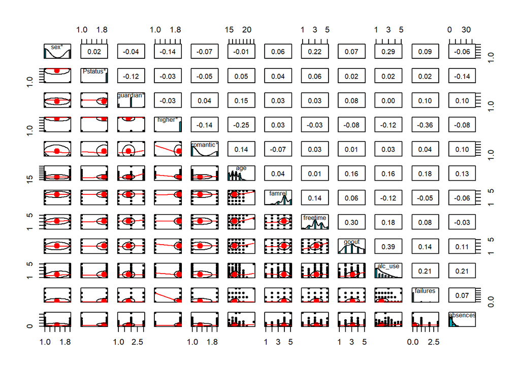

```r
#Source data
alc <- read_csv("https://raw.githubusercontent.com/KimmoVehkalahti/Helsinki-Open-Data-Science/master/datasets/alc.csv", show_col_types=FALSE)
library(ggplot2)
library(GGally)
#These are the possible columns of interest
MyVar <- c("sex","Pstatus","guardian","higher","romantic","age","famrel","freetime","goout","alc_use","failures","absences")
library(psych)
pairs.panels(alc[,MyVar],
             method = "pearson", # correlation method
             hist.col = "#00AFBB",
             density = TRUE,  # show density plots
             )
```

**4 variables of interest** 1. Going out (free time is correlated to this, and therefore i am choosing not to include that to avoid collinearity) and 2. Sex 3. Absences 4. Failures

These are in descending order of Pearson’s correlation coefficient score presented in pairs plot. I thought about removing failures and including age instead, because i thought absences would explain exam failures, but the correlation between these two is only 0.07, which indicates they are not hugely correlated and therefore not imposing collinearity issues further down the line.

#### **Task 3 - Numerically and graphically explore the chosen variables**

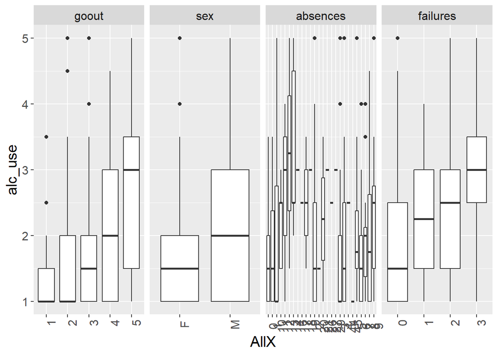

```r
library(tidyverse)
#Here i choose subset of social variables that interest me
cols_interest<-dplyr::select(alc,c("goout","sex","absences","failures","alc_use"))

#Further subset of variables that i am going to plot
GatherTheseCols <- c("goout","sex","absences","failures")
interest_long<- gather(data = cols_interest,
                  key = "ID",
                  value = "AllX",
                  GatherTheseCols,
                  factor_key = TRUE)
interest_plot<-ggplot(data = interest_long, aes(y=alc_use,x=AllX)) +
      geom_boxplot()+
      theme(text = element_text(size=15))+facet_grid(.~ID,scales="free_x")+
      theme(axis.text.x = element_text(angle=90))
interest_plot
```

Absences and alcohol intake have potentially non-linear relationship! The rest are quite predictable. Males’ intake of alcohol is higher than females, going out more is highly correlated with high alcohol use. The number of failures in class in the past is associated with higher alcohol intake. Interesting correlation/causation question there…Does past failures cause self-confidence issues relating to alcohol abuse or higher alcohol intake is likely to make you fall behind school and therefore becoming the cause of failures in classes? Further investigation needed.

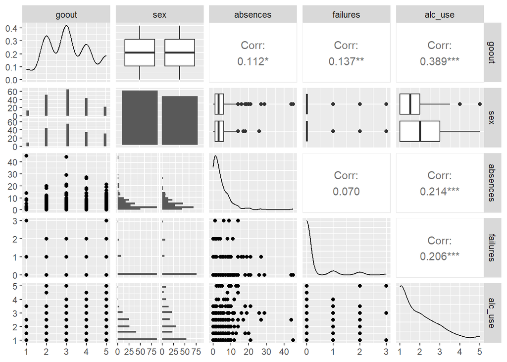

```r
library(GGally)
library(finalfit)
cols_interest%>%
  remove_labels() %>%
  ggpairs()
```

This suggests that absences have very little impact on failures. Interesting…A bit further investigation to explore what the impact of going out has on failures and alcohol consumption.

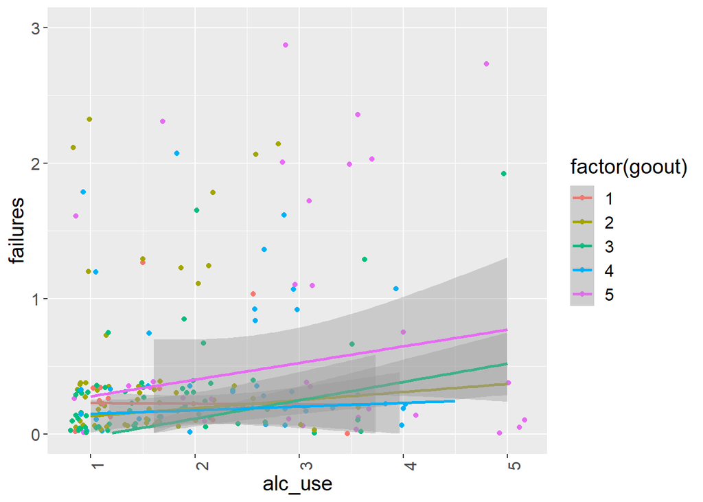

```r
goout_failures<-ggplot(data = cols_interest, aes(y=failures,x=alc_use,colour=factor(goout))) +
      geom_jitter()+geom_smooth(method="lm")+
  scale_fill_viridis_c()+
      theme(text = element_text(size=15))+
      theme(axis.text.x = element_text(angle=90))+
  ylim(c(0,3))
goout_failures
```

From this we can confirm that high alcohol use is related to higher number of past failures. And the more social drinking (going out a lot) is also associated with exam failures. Slopes are slightly different for “go out” factor, suggesting that there maybe some non -linear relationships going on.

#### **Task 4 - Logistic regression**

```r
logdata<-dplyr::select(alc,c("goout","sex","absences","failures","alc_use","high_use"))
str(logdata)
```

```
## tibble [370 × 6] (S3: tbl_df/tbl/data.frame)
##  $ goout   : num [1:370] 4 3 2 2 2 2 4 4 2 1 ...
##  $ sex     : chr [1:370] "F" "F" "F" "F" ...
##  $ absences: num [1:370] 5 3 8 1 2 8 0 4 0 0 ...
##  $ failures: num [1:370] 0 0 2 0 0 0 0 0 0 0 ...
##  $ alc_use : num [1:370] 1 1 2.5 1 1.5 1.5 1 1 1 1 ...
##  $ high_use: logi [1:370] FALSE FALSE TRUE FALSE FALSE FALSE ...
```

```r
#Sex is a character here. We have to turn this into a factor for GLM to treat it properly. While we are at it, do the same for logical var high_use as this will be our response variable in the binomial model
logdata$sex<-as.factor(logdata$sex)
logdata$high_use<-as.factor(logdata$high_use)

bin_full<- glm(high_use ~ failures + absences + sex + goout, data = logdata, family = "binomial")
summary(bin_full)
```

```
##
## Call:
## glm(formula = high_use ~ failures + absences + sex + goout, family = "binomial",
##     data = logdata)
##
## Coefficients:
##             Estimate Std. Error z value Pr(>|z|)
## (Intercept) -4.14389    0.47881  -8.654  < 2e-16 ***
## failures     0.48932    0.23073   2.121 0.033938 *
## absences     0.08246    0.02266   3.639 0.000274 ***
## sexM         0.97989    0.26156   3.746 0.000179 ***
## goout        0.69801    0.12093   5.772 7.83e-09 ***
## ---
## Signif. codes:  0 '***' 0.001 '**' 0.01 '*' 0.05 '.' 0.1 ' ' 1
##
## (Dispersion parameter for binomial family taken to be 1)
##
##     Null deviance: 452.04  on 369  degrees of freedom
## Residual deviance: 369.50  on 365  degrees of freedom
## AIC: 379.5
##
## Number of Fisher Scoring iterations: 4
```

This suggests that all predictors (sex, failures, going out and absences) are significant in the model at 95% level or above. Students’ sex, social habits (going out) and failures have relatively high impact on determining whether student belong to high alcohol intake classification (log(odds(high_use))). The odds ratio for these variables are 2.66, 2 and 1.63 respectively. We get this by exp() of corresponding estimate values. Surprisingly, absences have the least impact on the likelihood of student’s likelihood of being in high alcohol group. Alternatively, we just get the tidy() function like below.

```r
library(broom)
bin_full %>%
  tidy(conf.int = TRUE, exp = TRUE)
```

```
## # A tibble: 5 × 7
##   term        estimate std.error statistic  p.value conf.low conf.high
##   <chr>          <dbl>     <dbl>     <dbl>    <dbl>    <dbl>     <dbl>
## 1 (Intercept)   0.0159    0.479      -8.65 4.95e-18  0.00595    0.0391
## 2 failures      1.63      0.231       2.12 3.39e- 2  1.04       2.59
## 3 absences      1.09      0.0227      3.64 2.74e- 4  1.04       1.14
## 4 sexM          2.66      0.262       3.75 1.79e- 4  1.61       4.49
## 5 goout         2.01      0.121       5.77 7.83e- 9  1.59       2.56
```

Here we have the Odds ration under estimate column at 95% CI. Confidence intervals are in column 6 and 7, you will have to scroll back.

Since the summary() function above was not showing the residual information, which is perhaps the most important information about model fit. I am not sure why its missing…but i am going to get this manually.

```r
bin_full%>%glance()
```

```
## # A tibble: 1 × 8
##   null.deviance df.null logLik   AIC   BIC deviance df.residual  nobs
##           <dbl>   <int>  <dbl> <dbl> <dbl>    <dbl>       <int> <int>
## 1          452.     369  -185.  379.  399.     369.         365   370
```

Hmmm the df. residuals is high, so maybe further investigation is necessary, I am going the old fashioned way here.

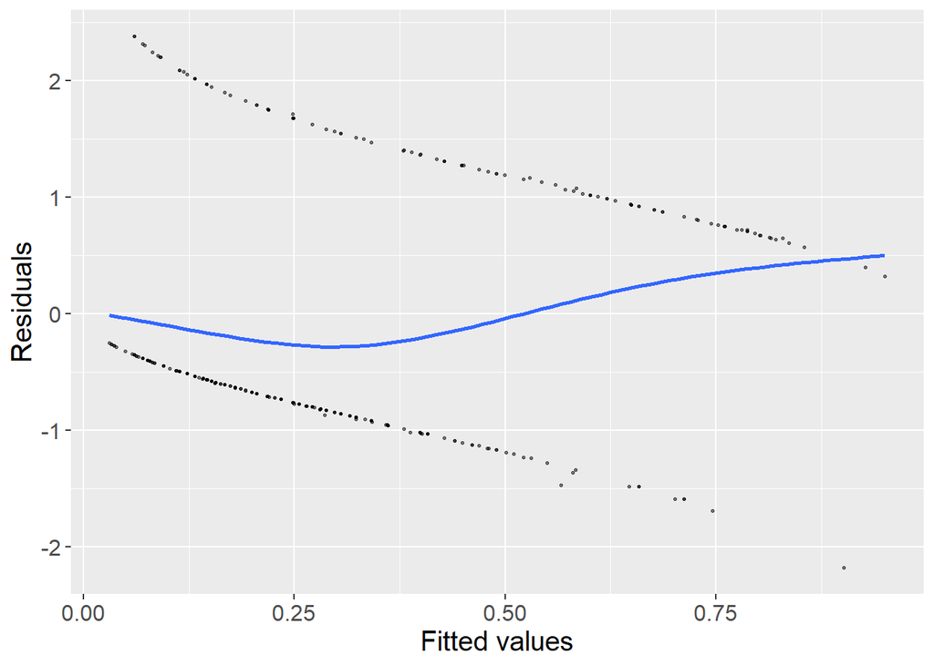

```r
r_binfull<-rstandard(bin_full)
f_binfull<-fitted(bin_full)


ggplot(data = bin_full, aes(x = f_binfull, y = r_binfull)) +
    geom_point( size = 0.5, alpha = 0.5) +
    geom_smooth(method = "gam", se = FALSE) +
    labs(x = "Fitted values", y = "Residuals") +
    theme(text = element_text(size = 15))
```

This is not looking very good. The fact that there is some curvature on the shape of the residuals suggests to me the model fitting is less than perfect. Lets test this on a variable that wasn’t used in the model (this is a method proposed by Zuur et al., 2016.)

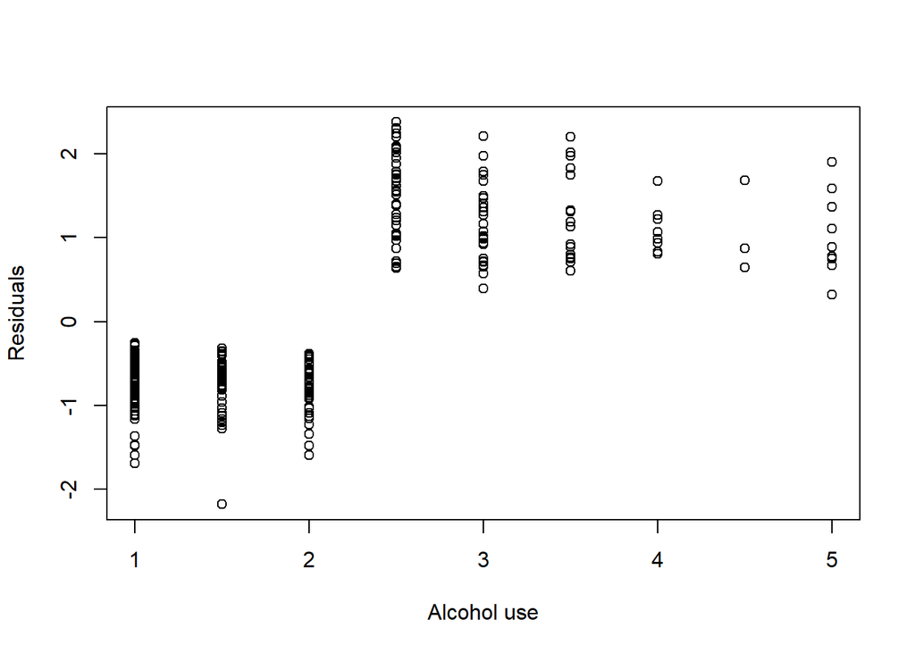

```r
plot(x = logdata$alc_use,
     y = r_binfull,
     xlab = "Alcohol use",
     ylab = "Residuals")
```

Ok suspicion confirmed. Model is clearly over dispersed at higher values of alcohol use. So further fine tuning of this model is necessary before it being fit for use. For the sake of this exercise however, i am going to continue with the bin_full model for now.

#### **Task 5 - Predict function**

The predict() function uses the fitted model to create probability values between 0 and 1. Its a very convenient way of using a logistic regression model output, as odds ratio and likelihood does my head in!

```r
prob_high_alc<- predict(bin_full, type = "response")
logdata<- mutate(logdata, prob = prob_high_alc)
logdata<-mutate(logdata,pred=prob>0.5)
```

##### Tabulating

```r
table(high_use=logdata$high_use,prediction=logdata$pred)
```

```
##         prediction
## high_use FALSE TRUE
##    FALSE   243   16
##    TRUE     61   50
```

A bit messy! Low false positives, but quite high false negatives! Error rate is usually calculated by (false positive+false negatives)/(Positive+negative) and accuracy is the inverse of this. Error is (61+16)/(243+16+61+50)=0.20 Accuracy is 1-error=0.8

To me there is a bit of a mismatch between the accuracy and model fitness. I’d say that model was not fit very well (residuals not completely random). there maybe some overfitting involved, which will push the accuracy metrics up.

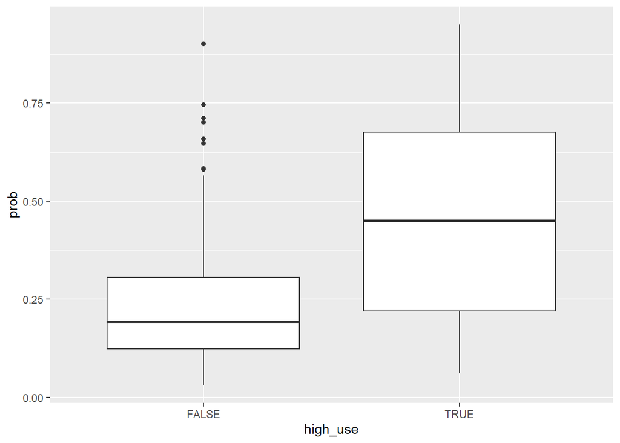

```r
g <- ggplot(logdata, aes(x = high_use, y = prob))+geom_boxplot()
g
```

Boxplot makes sense to me. Though there is a grey area where the TRUE and FALSE overlap a fair bit around probability of 0.2 and 0.4. Could go either way…that suggests a fair bit of misclassification at that end.

#### **Task 6 - Bonus**

To perform cross validation we need a loss function first, the use the boot library cv.glm function which gives us the average number of wrong predictions.

```r
loss_func <- function(class, prob) {
  n_wrong <- abs(class - prob) > 0.5
  mean(n_wrong)
}
library(boot)
cv <- cv.glm(data = logdata, cost = loss_func, glmfit = bin_full, K = 10)
cv$delta[1]
```

```
## [1] 0.2162162
```

```r
#0.21 which seems to correspond to the error that we calculated above by hand. And yes its better than the model given in example exercise, which didn't have going out as a predictor.
```

#### **Task 6 - Extra bonus**

```r
library(finalfit)
dependent <- "high_use"
explanatory <- c("sex","Pstatus","guardian","higher","romantic","age","famrel","freetime","goout","failures","absences")
explanatory_1<-c("sex","failures","absences","goout")

alc %>%
  finalfit(dependent, explanatory, explanatory_1,
           keep_models = TRUE, metrics = TRUE)
```

```
## [[1]]
##  Dependent: high_use                FALSE       TRUE
##                  sex         F 154 (79.0)  41 (21.0)
##                              M 105 (60.0)  70 (40.0)
##              Pstatus         A  26 (68.4)  12 (31.6)
##                              T 233 (70.2)  99 (29.8)
##             guardian    father  59 (67.0)  29 (33.0)
##                         mother 191 (71.8)  75 (28.2)
##                          other   9 (56.2)   7 (43.8)
##               higher        no   7 (43.8)   9 (56.2)
##                            yes 252 (71.2) 102 (28.8)
##             romantic        no 173 (68.9)  78 (31.1)
##                            yes  86 (72.3)  33 (27.7)
##                  age Mean (SD) 16.5 (1.2) 16.8 (1.2)
##               famrel Mean (SD)  4.0 (0.9)  3.8 (0.9)
##             freetime Mean (SD)  3.1 (1.0)  3.5 (0.9)
##                goout Mean (SD)  2.9 (1.0)  3.7 (1.1)
##             failures         0 238 (73.2)  87 (26.8)
##                              1  12 (50.0)  12 (50.0)
##                              2   8 (47.1)   9 (52.9)
##                              3   1 (25.0)   3 (75.0)
##             absences Mean (SD)  3.7 (4.5)  6.4 (7.1)
##        Coefficient (univariable) Coefficient (multivariable full)
##                                -                                -
##     0.19 (0.10 to 0.28, p<0.001)     0.17 (0.08 to 0.25, p<0.001)
##                                -                                -
##   -0.02 (-0.17 to 0.14, p=0.823)   -0.01 (-0.15 to 0.13, p=0.902)
##                                -                                -
##   -0.05 (-0.16 to 0.06, p=0.399)   -0.09 (-0.19 to 0.01, p=0.094)
##    0.11 (-0.14 to 0.35, p=0.387)    0.01 (-0.21 to 0.24, p=0.909)
##                                -                                -
##  -0.27 (-0.50 to -0.05, p=0.019)   -0.07 (-0.30 to 0.17, p=0.569)
##                                -                                -
##   -0.03 (-0.13 to 0.07, p=0.513)   -0.07 (-0.16 to 0.03, p=0.154)
##     0.04 (0.00 to 0.08, p=0.042)    0.01 (-0.03 to 0.05, p=0.693)
##  -0.06 (-0.11 to -0.01, p=0.019)  -0.07 (-0.12 to -0.03, p=0.002)
##     0.08 (0.03 to 0.12, p=0.002)    0.02 (-0.02 to 0.07, p=0.351)
##     0.14 (0.11 to 0.18, p<0.001)     0.13 (0.09 to 0.17, p<0.001)
##                                -                                -
##     0.23 (0.04 to 0.42, p=0.016)    0.15 (-0.02 to 0.33, p=0.087)
```

[output cut: 16 more lines]

```
##                              -
##                              -
##   0.13 (0.09 to 0.16, p<0.001)
##                              -
##   0.19 (0.01 to 0.36, p=0.035)
##  0.15 (-0.05 to 0.35, p=0.146)
##  0.27 (-0.14 to 0.67, p=0.200)
##   0.02 (0.01 to 0.02, p<0.001)
##
## [[2]]
## [[2]][[1]]
## [1] "Number in dataframe = 370, Number in model = 370, Missing = 0, Log-likelihood = -183.54, AIC = 399.1, R-squared = 0.25, Adjusted R-squared = 0.22"
##
## [[2]][[2]]
## [1] "Number in dataframe = 370, Number in model = 370, Missing = 0, Log-likelihood = -191.38, AIC = 398.8, R-squared = 0.22, Adjusted R-squared = 0.2"
```